# Asset Class Relationships with Growth and Inflation

```python
import numpy as np
import pandas as pd
import matplotlib.pyplot as plt
import matplotlib.dates as mdates
import seaborn as sns
import statsmodels.api as sm
from scipy import stats
from scipy.optimize import minimize

#needs blpapi to be installed
import pdblp
```

```python
%matplotlib inline
plt.rcParams['figure.figsize'] = (15, 10)
```

### Query data from Bloomberg

```python
con = pdblp.BCon(port=8194)
con.start()

# bloomberg indices
historical_tickers = [
    'G0O1 Index',
    'LUATTRUU Index',
    'LBUTTRUU Index',
    'BCOMTR Index',
    'SPX Index',
    'BCOMGCTR Index',
    'JPEIGLBL Index',
    'LF98TRUU Index',
    'LT08TRUU Index'
]

names = [
    'RF',
    'US Tsy',
    'US Tips',
    'Commodities',
    'US Equities',
    'Gold',
    'EM Bonds',
    'HY Bonds',
    'Intermediate US Tsy'
]

flds = ['PX_LAST']
startDate = 19701231
rdf = con.bdh(historical_tickers, flds, startDate, '')

# remove multiindex
rdf.columns = rdf.columns.droplevel(1)
rdf = rdf.rename(columns=dict(zip(historical_tickers,names)))

# convert to monthly
rdf = rdf.resample('M').last()

# % change
rdf = rdf.pct_change()

con.stop()
rdf.tail()
```

| ticker date | Intermediate US Tsy | RF | US Tsy | US Tips | Commodities | US Equities | Gold | EM Bonds | HY Bonds |
| --- | --- | --- | --- | --- | --- | --- | --- | --- | --- |
| 2018-01-31 | -0.009758 | 0.001193 | -0.013584 | -0.008574 | 0.019859 | 0.056179 | 0.023434 | -0.001956 | 0.005995 |
| 2018-02-28 | -0.002999 | 0.000946 | -0.007534 | -0.009719 | -0.017295 | -0.038947 | -0.017578 | -0.019594 | -0.008498 |
| 2018-03-31 | 0.005320 | 0.001402 | 0.009430 | 0.010505 | -0.006215 | -0.026885 | 0.004056 | 0.003769 | -0.006041 |
| 2018-04-30 | -0.005799 | 0.001307 | -0.008100 | -0.000574 | 0.025845 | 0.002719 | -0.004543 | -0.014630 | 0.006507 |
| 2018-05-31 | -0.002593 | 0.000971 | -0.005215 | -0.008215 | 0.013817 | 0.033342 | -0.023014 | -0.018838 | 0.000057 |

```python
print("Start Dates")
for i,n in enumerate(names):
    null_mask = pd.isnull(rdf[n])
    print("%s : %s" % (n, str(rdf.loc[null_mask,n].index[-1].date())))
```

```
Start Dates
RF : 1977-12-31
US Tsy : 1973-01-31
US Tips : 1997-03-31
Commodities : 1991-01-31
US Equities : 1970-12-31
Gold : 1991-01-31
EM Bonds : 1993-12-31
HY Bonds : 1983-07-31
Intermediate US Tsy : 1973-01-31
```

### Growth & Inflation Data

```python
gidf = pd.read_csv('macrodf.csv')
gidf = gidf.set_index('date')
gidf.head(15).tail(5)
```

| date | INDPRO | INDPRO Trend | dindprod3 | INDPRO Monthly | INDPRO Quarterly | INDPRO Forecast Surprise | INDPRO Forecast Surprise Normalized | INDPRO Forecast Surprise Signal | INDPRO Trend Surprise | INDPRO Trend Surprise Normalized | ... | CPURNSA Index Monthly | CPURNSA Index Quarterly | CPI Forecast Surprise | CPI Forecast Surprise Normalized | CPI Forecast Surprise Signal | CPI Trend Surprise | CPI Trend Surprise Normalized | CPI Trend Surprise Signal | CPI Combined Surprise Normalized | CPI Combined Surprise Signal |
| --- | --- | --- | --- | --- | --- | --- | --- | --- | --- | --- | --- | --- | --- | --- | --- | --- | --- | --- | --- | --- | --- |
| 1970-10-31 | 37.7154 | NaN | 0.048184 | -0.215307 | -0.014194 | -0.062378 | -1.039537 | 0.0 | NaN | NaN | ... | 0.062972 | 0.062645 | 0.032685 | 0.988772 | 1.0 | NaN | NaN | NaN | NaN | NaN |
| 1970-11-30 | 37.4870 | NaN | 0.048184 | -0.070298 | -0.014194 | -0.062378 | -1.039537 | 0.0 | NaN | NaN | ... | 0.062643 | 0.062645 | 0.032685 | 0.988772 | 1.0 | NaN | NaN | NaN | NaN | NaN |
| 1970-12-31 | 38.3479 | NaN | 0.048184 | 0.313200 | -0.014194 | -0.062378 | -1.039537 | 0.0 | NaN | NaN | ... | 0.062318 | 0.062645 | 0.032685 | 0.988772 | 1.0 | NaN | NaN | NaN | NaN | NaN |
| 1971-01-31 | 38.6429 | -0.036150 | 0.154570 | 0.096320 | 0.018855 | -0.135715 | -2.261695 | 0.0 | 0.132470 | 1.545854 | ... | 0.000000 | 0.020253 | -0.016760 | -0.507037 | 0.0 | -0.055725 | -1.417889 | 0.0 | -0.962463 | 0.0 |
| 1971-02-28 | 38.5692 | -0.010502 | 0.154570 | -0.022648 | 0.018855 | -0.135715 | -2.261695 | 0.0 | -0.012146 | -0.141738 | ... | 0.030571 | 0.020253 | -0.016760 | -0.507037 | 0.0 | -0.022370 | -0.569183 | 0.0 | -0.538110 | 0.0 |

5 rows × 26 columns

### Combine Growth and Inflation surprise data with monthly return data

```python
rdf2 = pd.merge(
    rdf,
    gidf.loc[:,
             [
                 'INDPRO Forecast Surprise Normalized',
                 'INDPRO Forecast Surprise Signal',
                 'INDPRO Trend Surprise Normalized',
                 'INDPRO Trend Surprise Signal',
                 'INDPRO Combined Surprise Normalized',
                 'INDPRO Combined Surprise Signal',
                 'CPI Forecast Surprise Signal',
                 'CPI Forecast Surprise Normalized',
                 'CPI Trend Surprise Signal',
                 'CPI Trend Surprise Normalized',
                 'CPI Combined Surprise Signal',
                 'CPI Combined Surprise Normalized'
             ]
            ],
    how='left',
    left_index=True,
    right_index=True
)

# start at 73
start73_mask = rdf2.index >= pd.datetime(1973,1,1)

# end in 2017
end17_mask = rdf2.index <= pd.datetime(2017,12,31)

rdf2 = rdf2[(start73_mask & end17_mask)]
rdf2.head(12)
```

| date | Intermediate US Tsy | RF | US Tsy | US Tips | Commodities | US Equities | Gold | EM Bonds | HY Bonds | INDPRO Forecast Surprise Normalized | ... | INDPRO Trend Surprise Normalized | INDPRO Trend Surprise Signal | INDPRO Combined Surprise Normalized | INDPRO Combined Surprise Signal | CPI Forecast Surprise Signal | CPI Forecast Surprise Normalized | CPI Trend Surprise Signal | CPI Trend Surprise Normalized | CPI Combined Surprise Signal | CPI Combined Surprise Normalized |
| --- | --- | --- | --- | --- | --- | --- | --- | --- | --- | --- | --- | --- | --- | --- | --- | --- | --- | --- | --- | --- | --- |
| 1973-01-31 | NaN | NaN | NaN | NaN | NaN | -0.017111 | NaN | NaN | NaN | 0.039900 | ... | -0.418739 | 0.0 | -0.189419 | 0.0 | 1.0 | 1.091699 | 0.0 | -0.139196 | 1.0 | 0.476251 |
| 1973-02-28 | -0.002728 | NaN | -0.002627 | NaN | NaN | -0.037490 | NaN | NaN | NaN | 0.039900 | ... | 1.127057 | 1.0 | 0.583478 | 1.0 | 1.0 | 1.091699 | 1.0 | 1.306703 | 1.0 | 1.199201 |
| 1973-03-31 | -0.000101 | NaN | 0.000000 | NaN | NaN | -0.001433 | NaN | NaN | NaN | 0.039900 | ... | -1.134075 | 0.0 | -0.547088 | 0.0 | 1.0 | 1.091699 | 1.0 | 2.011483 | 1.0 | 1.551591 |
| 1973-04-30 | 0.009422 | NaN | 0.009420 | NaN | NaN | -0.040800 | NaN | NaN | NaN | -0.751921 | ... | -1.296970 | 0.0 | -1.024445 | 0.0 | 1.0 | 1.524280 | 1.0 | 1.029460 | 1.0 | 1.276870 |
| 1973-05-31 | 0.002609 | NaN | 0.002208 | NaN | NaN | -0.018884 | NaN | NaN | NaN | -0.751921 | ... | -0.048449 | 0.0 | -0.400185 | 0.0 | 1.0 | 1.524280 | 1.0 | 0.893858 | 1.0 | 1.209069 |
| 1973-06-30 | 0.002803 | NaN | 0.002703 | NaN | NaN | -0.006575 | NaN | NaN | NaN | -0.751921 | ... | -0.953548 | 0.0 | -0.852734 | 0.0 | 1.0 | 1.524280 | 1.0 | 0.759103 | 1.0 | 1.141691 |
| 1973-07-31 | -0.020463 | NaN | -0.021068 | NaN | NaN | 0.037982 | NaN | NaN | NaN | -0.338602 | ... | -0.435311 | 0.0 | -0.386957 | 0.0 | 1.0 | 1.530190 | 0.0 | -0.826893 | 1.0 | 0.351648 |
| 1973-08-31 | 0.019260 | NaN | 0.019584 | NaN | NaN | -0.036685 | NaN | NaN | NaN | -0.338602 | ... | -1.321467 | 0.0 | -0.830035 | 0.0 | 1.0 | 1.530190 | 1.0 | 4.637495 | 1.0 | 3.083843 |
| 1973-09-30 | 0.021196 | NaN | 0.022009 | NaN | NaN | 0.040096 | NaN | NaN | NaN | -0.338602 | ... | 0.420102 | 1.0 | 0.040750 | 1.0 | 1.0 | 1.530190 | 0.0 | -1.195778 | 1.0 | 0.167206 |
| 1973-10-31 | 0.009007 | NaN | 0.008320 | NaN | NaN | -0.001291 | NaN | NaN | NaN | 0.119594 | ... | 0.070373 | 1.0 | 0.094983 | 1.0 | 1.0 | 1.267344 | 1.0 | 0.960874 | 1.0 | 1.114109 |
| 1973-11-30 | 0.005434 | NaN | 0.005825 | NaN | NaN | -0.113861 | NaN | NaN | NaN | 0.119594 | ... | -0.072431 | 0.0 | 0.023582 | 1.0 | 1.0 | 1.267344 | 1.0 | 0.094876 | 1.0 | 0.681110 |
| 1973-12-31 | -0.000097 | NaN | -0.000965 | NaN | NaN | 0.016569 | NaN | NaN | NaN | 0.119594 | ... | -1.074948 | 0.0 | -0.477677 | 0.0 | 1.0 | 1.267344 | 0.0 | -0.034355 | 1.0 | 0.616494 |

12 rows × 21 columns

```python
# convert to spread indices to remove Tsy component
rdf2['HY Spread'] = rdf2['HY Bonds'] - rdf2['Intermediate US Tsy']
rdf2['EM Spread'] = rdf2['EM Bonds'] - rdf2['Intermediate US Tsy']
```

```python
signal_cols_dict = {
    'Forecast' : ('INDPRO Forecast Surprise Signal','CPI Forecast Surprise Signal'),
    'Trend' : ('INDPRO Trend Surprise Signal','CPI Trend Surprise Signal'),
    'Combined' : ('INDPRO Combined Surprise Signal','CPI Combined Surprise Signal')
}

cash_ticker = 'RF'

tickers = np.array(
    [
        'US Tsy',
        'US Tips',
        'US Equities',
        'Commodities',
        'Gold',
        'HY Spread',
        'EM Spread'
    ]
)

macro_environments = np.array([
                'All',
                'Growth Up',
                'Growth Down',
                'Inflation Up',
                'Inflation Down',
                'Growth Up + Inflation Up',
                'Growth Up + Inflation Down',
                'Growth Down + Inflation Up',
                'Growth Down + Inflation Down'
            ])

macro_envs_ordered = np.array([
    'Growth Down + Inflation Down',
    'Growth Up + Inflation Down',
    'Growth Down + Inflation Up',
    'Growth Up + Inflation Up'
])
```

```python
def create_macro_environment_masks(
    rdf:pd.DataFrame,
    signal_type:str,
    sc_dict:dict=signal_cols_dict
) -> pd.DataFrame:

    mdf = pd.DataFrame(index=rdf.index)

    mdf['Growth Up'] = rdf[sc_dict[signal_type][0]] > 0.9
    mdf['Growth Down'] = rdf[sc_dict[signal_type][0]] < 0.1
    mdf['Inflation Up'] = rdf[sc_dict[signal_type][1]] > 0.9
    mdf['Inflation Down'] = rdf[sc_dict[signal_type][1]] < 0.1

    mdf['Growth Up + Inflation Up'] = mdf['Growth Up'] & mdf['Inflation Up']
    mdf['Growth Up + Inflation Down'] = mdf['Growth Up'] & mdf['Inflation Down']
    mdf['Growth Down + Inflation Up'] = mdf['Growth Down'] & mdf['Inflation Up']
    mdf['Growth Down + Inflation Down'] = mdf['Growth Down'] & mdf['Inflation Down']
    return mdf

def print_macro_environment_masks(mdf:pd.DataFrame) -> None:
    print("Rising Growth number of Months: %i" % np.nansum(mdf['Growth Up']))
    print("Rising Growth %% of Months: %.2f%%" % (np.nanmean(mdf['Growth Up'])*100))
    print("Falling Growth number of Months: %i" % np.nansum(mdf['Growth Down']))
    print("Falling Growth %% of Months: %.2f%%" % (np.nanmean(mdf['Growth Down'])*100))
    print("Rising Inflation number of Months: %i" % np.nansum(mdf['Inflation Up']))
    print("Rising Inflation %% of Months: %.2f%%" % (np.nanmean(mdf['Inflation Up'])*100))
    print("Falling Inflation number of Months: %i" % np.nansum(mdf['Inflation Down']))
    print("Falling Inflation %% of Months: %.2f%%" % (np.nanmean(mdf['Inflation Down'])*100))
    print("Rising Growth + Rising Inflation number of Months: %i" % np.nansum(mdf['Growth Up + Inflation Up']))
    print("Rising Growth + Rising Inflation %% of Months: %.2f%%" % (np.nanmean(mdf['Growth Up + Inflation Up'])*100))
    print("Rising Growth + Falling Inflation number of Months: %i" % np.nansum(mdf['Growth Up + Inflation Down']))
    print("Rising Growth + Falling Inflation %% of Months: %.2f%%" % (np.nanmean(mdf['Growth Up + Inflation Down'])*100))
    print("Falling Growth + Rising Inflation number of Months: %i" % np.nansum(mdf['Growth Down + Inflation Up']))
    print("Falling Growth + Rising Inflation %% of Months: %.2f%%" % (np.nanmean(mdf['Growth Down + Inflation Up'])*100))
    print("Falling Growth + Falling Inflation number of Months: %i" % np.nansum(mdf['Growth Down + Inflation Down']))
    print("Falling Growth + Falling Inflation %% of Months: %.2f%%" % (np.nanmean(mdf['Growth Down + Inflation Down'])*100))
    return
```

```python
def calculate_sharpes_in_macro_envs(
    rdf:pd.DataFrame,
    mdf:pd.DataFrame,
    macro_environments:np.ndarray,
    tickers:np.ndarray,
    cash_ticker:str=cash_ticker) -> pd.DataFrame:

    resdf = pd.DataFrame(
        np.zeros((len(tickers),len(macro_environments))),
        index=tickers,
        columns=macro_environments
    )

    for t in tickers:
        #no need to subtract the risk free in self financing portfolios
        #this assumes going long HY and short duration matched treasuries is dollar neutral
        if t in ("HY Spread","EMD Spread"):
            for m in macro_environments:
                if m == 'All':
                    resdf.loc[t,m] = (
                        np.mean(rdf.loc[:,t])/np.std(rdf.loc[:,t],ddof=1)*np.sqrt(12)
                    )
                else:
                    mask = mdf[m]
                    resdf.loc[t,m] = (
                        np.mean(rdf.loc[mask,t])/np.std(rdf.loc[mask,t],ddof=1)*np.sqrt(12)
                    )
        else:
            for m in macro_environments:
                if m == 'All':
                    resdf.loc[t,m] = (
                        np.mean(rdf.loc[:,t] - rdf.loc[:,cash_ticker])/np.std(rdf.loc[:,t],ddof=1)*np.sqrt(12)
                    )
                else:
                    mask = mdf[m]
                    resdf.loc[t,m] = (
                        np.mean(rdf.loc[mask,t] - rdf.loc[mask,cash_ticker])/np.std(rdf.loc[mask,t])*np.sqrt(12)
                    )
    return resdf
```

## Examine Relationships with Macro Environments

```python
signal_type = 'Forecast'
print(signal_type)

mdf_fc = create_macro_environment_masks(rdf2,signal_type,sc_dict=signal_cols_dict)
print_macro_environment_masks(mdf_fc)

signal_type = 'Trend'
print()
print(signal_type)

mdf_trend = create_macro_environment_masks(rdf2,signal_type,sc_dict=signal_cols_dict)
print_macro_environment_masks(mdf_trend)

signal_type = 'Combined'
print()
print(signal_type)

mdf_combined = create_macro_environment_masks(rdf2,signal_type,sc_dict=signal_cols_dict)
print_macro_environment_masks(mdf_combined)
```

```
Forecast
Rising Growth number of Months: 237
Rising Growth % of Months: 43.89%
Falling Growth number of Months: 303
Falling Growth % of Months: 56.11%
Rising Inflation number of Months: 276
Rising Inflation % of Months: 51.11%
Falling Inflation number of Months: 264
Falling Inflation % of Months: 48.89%
Rising Growth + Rising Inflation number of Months: 120
Rising Growth + Rising Inflation % of Months: 22.22%
Rising Growth + Falling Inflation number of Months: 117
Rising Growth + Falling Inflation % of Months: 21.67%
Falling Growth + Rising Inflation number of Months: 156
Falling Growth + Rising Inflation % of Months: 28.89%
Falling Growth + Falling Inflation number of Months: 147
Falling Growth + Falling Inflation % of Months: 27.22%

Trend
Rising Growth number of Months: 252
Rising Growth % of Months: 46.67%
Falling Growth number of Months: 288
Falling Growth % of Months: 53.33%
Rising Inflation number of Months: 268
Rising Inflation % of Months: 49.63%
Falling Inflation number of Months: 272
Falling Inflation % of Months: 50.37%
Rising Growth + Rising Inflation number of Months: 126
Rising Growth + Rising Inflation % of Months: 23.33%
Rising Growth + Falling Inflation number of Months: 126
Rising Growth + Falling Inflation % of Months: 23.33%
Falling Growth + Rising Inflation number of Months: 142
Falling Growth + Rising Inflation % of Months: 26.30%
Falling Growth + Falling Inflation number of Months: 146
Falling Growth + Falling Inflation % of Months: 27.04%

Combined
Rising Growth number of Months: 234
Rising Growth % of Months: 43.33%
Falling Growth number of Months: 306
Falling Growth % of Months: 56.67%
Rising Inflation number of Months: 280
Rising Inflation % of Months: 51.85%
Falling Inflation number of Months: 260
Falling Inflation % of Months: 48.15%
Rising Growth + Rising Inflation number of Months: 116
Rising Growth + Rising Inflation % of Months: 21.48%
Rising Growth + Falling Inflation number of Months: 118
Rising Growth + Falling Inflation % of Months: 21.85%
Falling Growth + Rising Inflation number of Months: 164
Falling Growth + Rising Inflation % of Months: 30.37%
Falling Growth + Falling Inflation number of Months: 142
Falling Growth + Falling Inflation % of Months: 26.30%
```

```python
mdf_fc.head()
```

| date | Growth Up | Growth Down | Inflation Up | Inflation Down | Growth Up + Inflation Up | Growth Up + Inflation Down | Growth Down + Inflation Up | Growth Down + Inflation Down |
| --- | --- | --- | --- | --- | --- | --- | --- | --- |
| 1973-01-31 | True | False | True | False | True | False | False | False |
| 1973-02-28 | True | False | True | False | True | False | False | False |
| 1973-03-31 | True | False | True | False | True | False | False | False |
| 1973-04-30 | False | True | True | False | False | False | True | False |
| 1973-05-31 | False | True | True | False | False | False | True | False |

```python
sdf_fc = calculate_sharpes_in_macro_envs(
    rdf2,
    mdf_fc,
    macro_environments,
    tickers,
    cash_ticker
)
print("Sharpes using Forecasts to determine economic surprises")
sdf_fc
```

```
Sharpes using Forecasts to determine economic surprises
```

|  | All | Growth Up | Growth Down | Inflation Up | Inflation Down | Growth Up + Inflation Up | Growth Up + Inflation Down | Growth Down + Inflation Up | Growth Down + Inflation Down |
| --- | --- | --- | --- | --- | --- | --- | --- | --- | --- |
| US Tsy | 0.428411 | -0.276634 | 0.940399 | -0.156826 | 1.030702 | -0.982884 | 0.484535 | 0.452903 | 1.424215 |
| US Tips | 0.595969 | 0.705667 | 0.572841 | 1.069588 | 0.186962 | 0.971618 | 0.460933 | 1.112372 | 0.105828 |
| US Equities | 0.304351 | 0.511230 | 0.147766 | 0.015521 | 0.574599 | 0.218235 | 0.769161 | -0.128623 | 0.418800 |
| Commodities | 0.048434 | 0.194872 | -0.031662 | 0.925863 | -0.600812 | 1.030526 | -0.351639 | 0.889166 | -0.776800 |
| Gold | 0.196202 | -0.174944 | 0.390413 | 0.580769 | -0.105153 | 0.143741 | -0.394584 | 0.796812 | 0.049177 |
| HY Spread | 0.331534 | 0.688105 | 0.171084 | 0.511622 | 0.203242 | 0.678269 | 0.693559 | 0.450176 | -0.037417 |
| EM Spread | 0.216728 | 0.244905 | 0.195162 | 0.316077 | 0.156891 | 0.279363 | 0.228962 | 0.362533 | 0.073793 |

```python
sdf_trend = calculate_sharpes_in_macro_envs(
    rdf2,
    mdf_trend,
    macro_environments,
    tickers,
    cash_ticker
)
print("Sharpes using Trend to determine economic surprises")
sdf_trend
```

```
Sharpes using Trend to determine economic surprises
```

|  | All | Growth Up | Growth Down | Inflation Up | Inflation Down | Growth Up + Inflation Up | Growth Up + Inflation Down | Growth Down + Inflation Up | Growth Down + Inflation Down |
| --- | --- | --- | --- | --- | --- | --- | --- | --- | --- |
| US Tsy | 0.428411 | -0.100160 | 0.859618 | -0.031529 | 0.824133 | -0.252020 | 0.047373 | 0.174401 | 1.426359 |
| US Tips | 0.595969 | 0.401801 | 0.800803 | 0.962579 | 0.246374 | 1.241037 | -0.372439 | 0.706317 | 0.902686 |
| US Equities | 0.304351 | 0.140430 | 0.455854 | 0.162900 | 0.442510 | 0.080633 | 0.195189 | 0.233819 | 0.685456 |
| Commodities | 0.048434 | 0.137757 | -0.028761 | 0.755240 | -0.506968 | 1.095019 | -0.664461 | 0.448225 | -0.384186 |
| Gold | 0.196202 | -0.048362 | 0.439289 | 0.536803 | -0.127869 | 0.445372 | -0.545549 | 0.631512 | 0.262990 |
| HY Spread | 0.331534 | 0.563227 | 0.116501 | 0.540625 | 0.154165 | 0.977317 | 0.224357 | 0.150136 | 0.087395 |
| EM Spread | 0.216728 | 0.002605 | 0.508284 | 0.316253 | 0.136026 | 0.042996 | -0.025483 | 0.592885 | 0.413677 |

```python
sdf_combined = calculate_sharpes_in_macro_envs(
    rdf2,
    mdf_combined,
    macro_environments,
    tickers,
    cash_ticker
)
print("Sharpes using a combination of Forecasts and Trend to determine economic surprises")
sdf_combined
```

```
Sharpes using a combination of Forecasts and Trend to determine economic surprises
```

|  | All | Growth Up | Growth Down | Inflation Up | Inflation Down | Growth Up + Inflation Up | Growth Up + Inflation Down | Growth Down + Inflation Up | Growth Down + Inflation Down |
| --- | --- | --- | --- | --- | --- | --- | --- | --- | --- |
| US Tsy | 0.428411 | -0.135346 | 0.823677 | -0.072197 | 0.978017 | -0.325796 | 0.085622 | 0.110760 | 1.622403 |
| US Tips | 0.595969 | 0.689787 | 0.532564 | 0.837444 | 0.355454 | 1.618555 | 0.013132 | 0.433800 | 0.656463 |
| US Equities | 0.304351 | 0.352841 | 0.265347 | 0.055174 | 0.550827 | 0.188578 | 0.489301 | -0.034866 | 0.614393 |
| Commodities | 0.048434 | 0.240848 | -0.093127 | 0.830841 | -0.546165 | 1.348310 | -0.475653 | 0.512922 | -0.604825 |
| Gold | 0.196202 | -0.038453 | 0.379596 | 0.572473 | -0.124419 | 0.457593 | -0.368321 | 0.645444 | 0.105501 |
| HY Spread | 0.331534 | 0.484982 | 0.228030 | 0.478278 | 0.207099 | 0.806551 | 0.274630 | 0.304262 | 0.152295 |
| EM Spread | 0.216728 | 0.098410 | 0.360033 | 0.273928 | 0.177846 | 0.459710 | -0.091158 | 0.142610 | 0.619010 |

##### Differences between macroenvironments based on forecasts and macroenvironments based on trend:

- The relationship between equities and growth is positive as expected when using forecasts but the relationship is negative when using trend to determine economic surprises.
- The relationship between EMD and growth is positive as expected when using forecasts but the relationship is negative when using trend.

This is one piece of information that leads me to like forecasts over trend to determine economic surprises but it isn't strong evidence.

```python
def plot_sharpes_across_macroenvironments(
    resdf:pd.DataFrame,
    macroenvironments:list,
    type_of_macro_forecast=None
):
    colors = ['blue','gray','red','orange','gold','purple','pink']
    for i,t in enumerate(resdf.index):
        plt.scatter(
            macroenvironments,
            resdf.loc[t,macroenvironments],
            label=t,
            color=colors[i]
        )
        plt.axhline(y=resdf.loc[t,'All'],color=colors[i])
    plt.axhline(y=0,color='gray',linestyle='dashed')
    plt.title("Sharpes Across Macroenvironments")
    plt.legend()

    if type_of_macro_forecast is not None:
        plt.annotate(
            "*Macroenvironment Surprises calculated using %s" % type_of_macro_forecast,
            (0, 0),
            (0, -40),
            xycoords='axes fraction',
            textcoords='offset points',
            va='top'
        )

    plt.show()
```

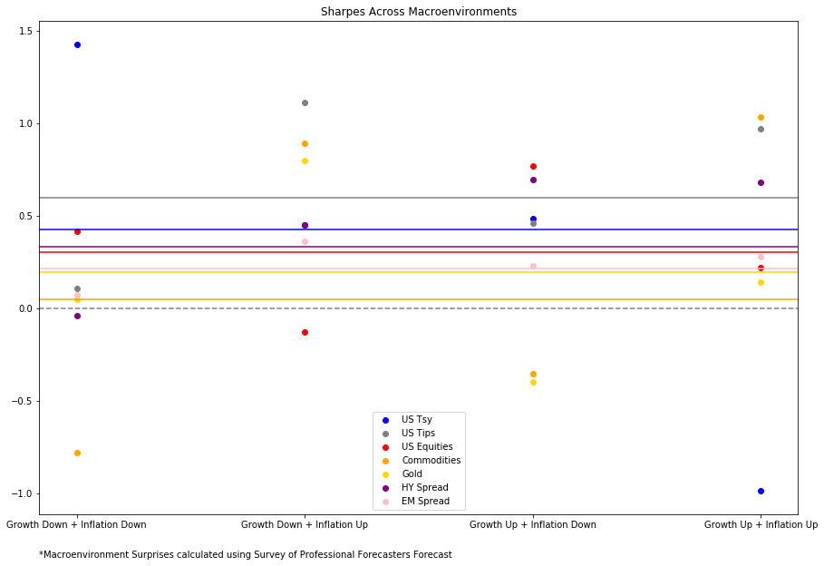

```python
plot_sharpes_across_macroenvironments(
    sdf_fc,
    macro_environments[5:9],
    "Survey of Professional Forecasters Forecast"
)
```

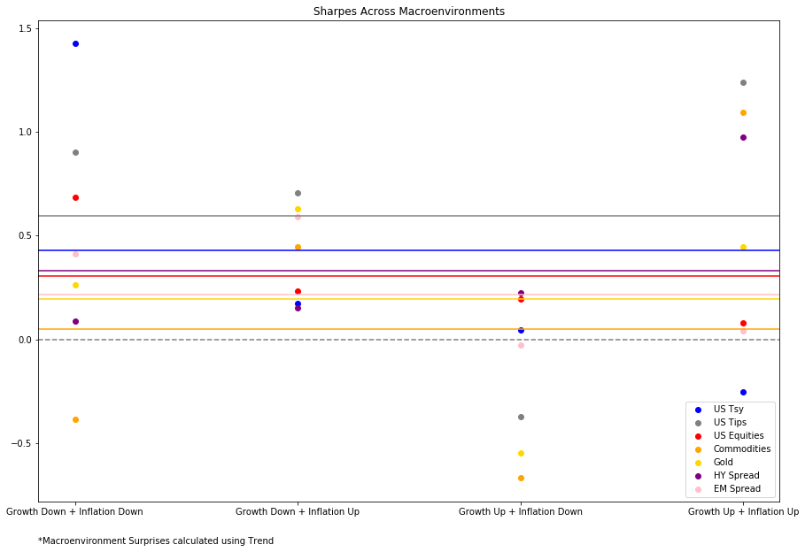

```python
plot_sharpes_across_macroenvironments(
    sdf_trend,
    macro_environments[5:9],
    "Trend"
)
```

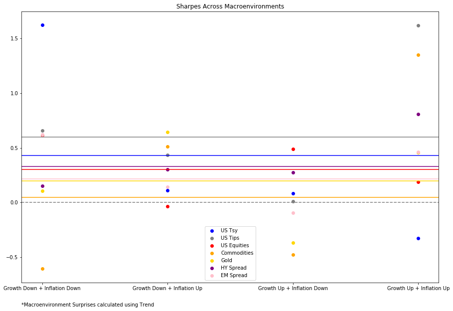

```python
plot_sharpes_across_macroenvironments(
    sdf_combined,
    macro_environments[5:9],
    "Trend"
)
```

##### Looking at the performance for each asset class in different macroenvironments:

- US Treasuries - perform well in Growth Down and Inflation Down.
- US Tips - performs well in Growth Down + Inflation Up as well as Growth Up + Inflation Up.
- US Equities - performs well in Growth Up and Inflation Down.
- Commodities - performs well in Growth Up + Inflation Up as well as Growth Down + Inflation Up.
- Gold - performs well in Growth Down + Inflation Up as you would expect.
- High Yield - HY Spread(long a High Yield bond index and short a duration matched treasury index) - performs well in growth up environments. The relationship with inflation in the data is positive but the economic theory behind the relationship suggests it should be negative if it is disinflation.
- Emerging Market Debt - EMD Spread(long a USD denominated emerging market debt index and short a duration matched treasury index) - performs well in a Growth Down and Inflation Up environment which is similar to commodities. The results vary depending on whether you use trend to determine economic surprises or if you use forecasts to determine economic surprises.

```python
def plot_relationship(
    rdf:pd.DataFrame,
    ticker:str,
    g_or_i:str,
    fc_or_trend:str
):
    type_of_macro_surprise = 'CPI'
    if g_or_i == 'Growth':
        type_of_macro_surprise = 'INDPRO'

    type_of_forecast = 'Forecast'
    if fc_or_trend == 'Trend':
        type_of_forecast = 'Trend'

    surprise_col_name = (
        "%s %s Surprise Normalized" %
        (
            type_of_macro_surprise,
            type_of_forecast
        )
    )

    tempdf = rdf.loc[:,[
        ticker,
        surprise_col_name
    ]].dropna()

    X = sm.add_constant(tempdf[surprise_col_name])
    y = tempdf[ticker]
    model = sm.OLS(y, X)
    results = model.fit()
    print("Beta of %s to %s: %0.4f" %
         (
             ticker,
             surprise_col_name,
             results.params[1]
         )
    )
    print("T statistic of Beta of %s to %s: %0.4f" %
         (
             ticker,
             surprise_col_name,
             results.tvalues[1]
         )
    )

    plt.scatter(
        tempdf[surprise_col_name],
        tempdf[ticker]
    )
    plt.plot(
        tempdf[surprise_col_name],
        results.fittedvalues,
        color='red',
        label='OLS'
    )
    plt.xlabel(
        "%s Suprise using %s" %
        (
            g_or_i,
            type_of_forecast
        )
    )
    plt.ylabel('Return')
    plt.legend()
    plt.show()

    return
```

```
US Tsy
Beta of US Tsy to INDPRO Forecast Surprise Normalized: -0.0034
T statistic of Beta of US Tsy to INDPRO Forecast Surprise Normalized: -5.4292
```

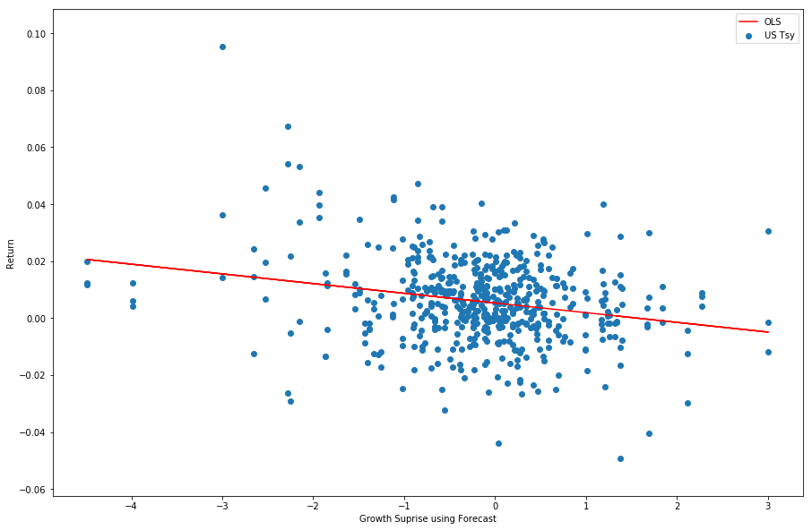

```
Beta of US Tsy to CPI Forecast Surprise Normalized: -0.0027
T statistic of Beta of US Tsy to CPI Forecast Surprise Normalized: -4.3363
```

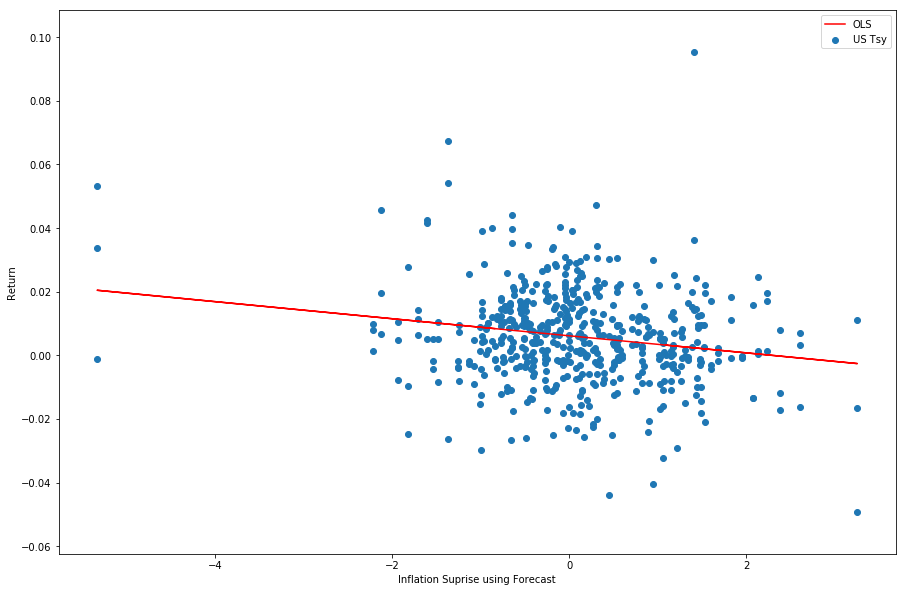

```
US Tips
Beta of US Tips to INDPRO Forecast Surprise Normalized: 0.0010
T statistic of Beta of US Tips to INDPRO Forecast Surprise Normalized: 0.8442
```

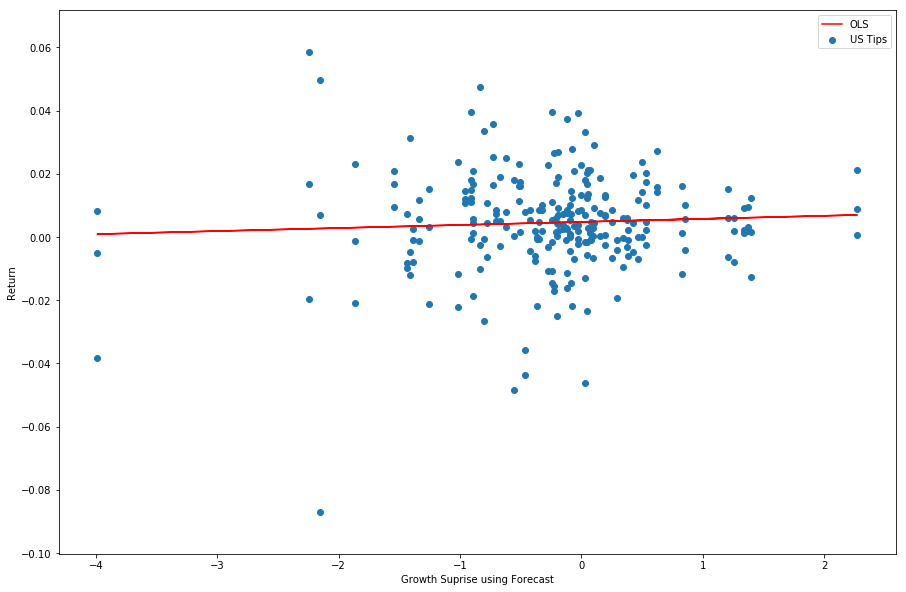

```
Beta of US Tips to CPI Forecast Surprise Normalized: 0.0017
T statistic of Beta of US Tips to CPI Forecast Surprise Normalized: 1.9403
```

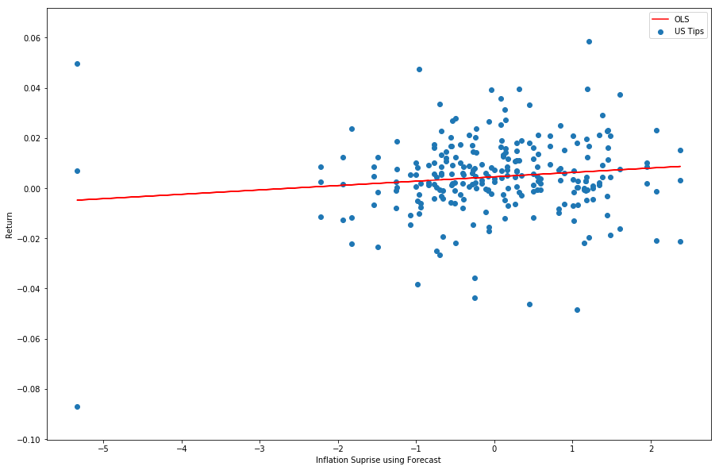

```
US Equities
Beta of US Equities to INDPRO Forecast Surprise Normalized: 0.0009
T statistic of Beta of US Equities to INDPRO Forecast Surprise Normalized: 0.4705
```

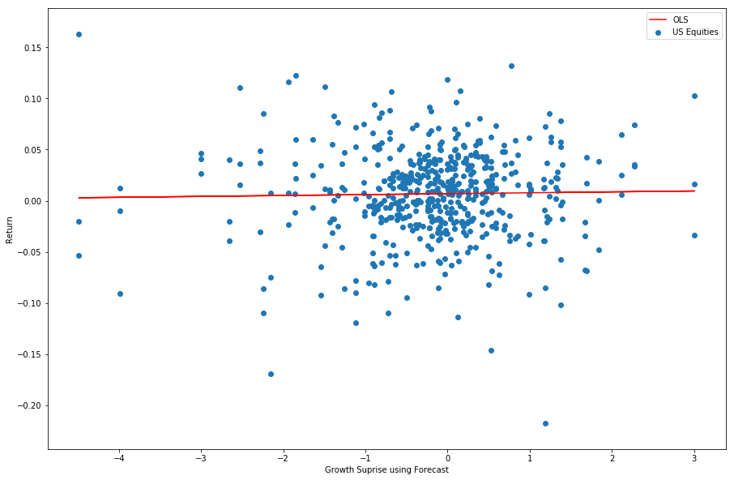

```
Beta of US Equities to CPI Forecast Surprise Normalized: -0.0034
T statistic of Beta of US Equities to CPI Forecast Surprise Normalized: -1.8406
```

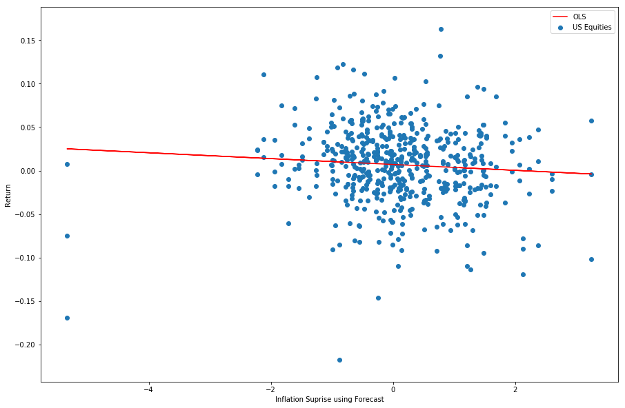

```
Commodities
Beta of Commodities to INDPRO Forecast Surprise Normalized: 0.0089
T statistic of Beta of Commodities to INDPRO Forecast Surprise Normalized: 3.3513
```

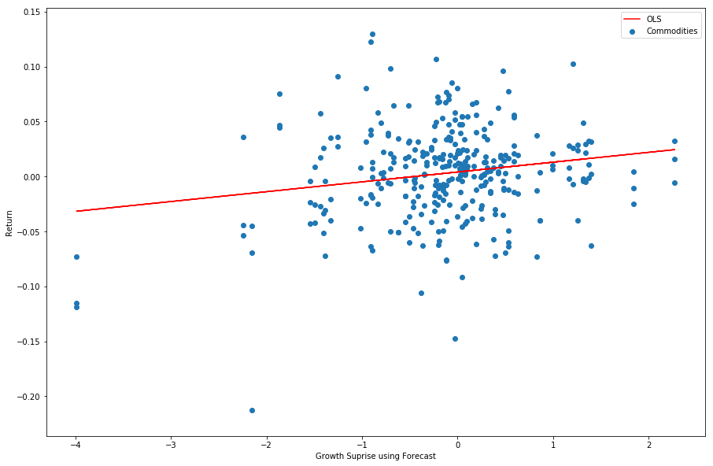

```
Beta of Commodities to CPI Forecast Surprise Normalized: 0.0144
T statistic of Beta of Commodities to CPI Forecast Surprise Normalized: 6.5938
```

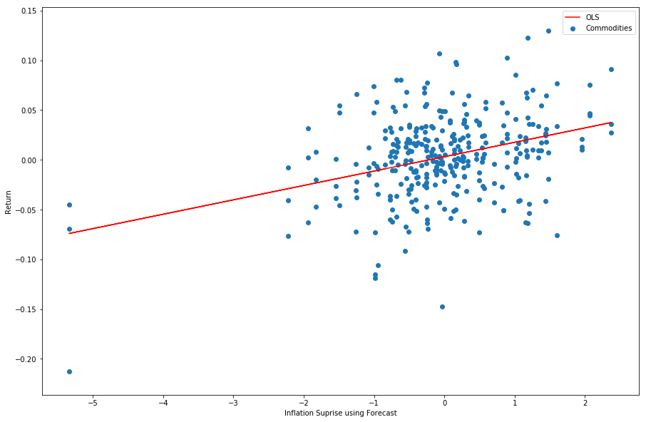

```
Gold
Beta of Gold to INDPRO Forecast Surprise Normalized: 0.0001
T statistic of Beta of Gold to INDPRO Forecast Surprise Normalized: 0.0436
```

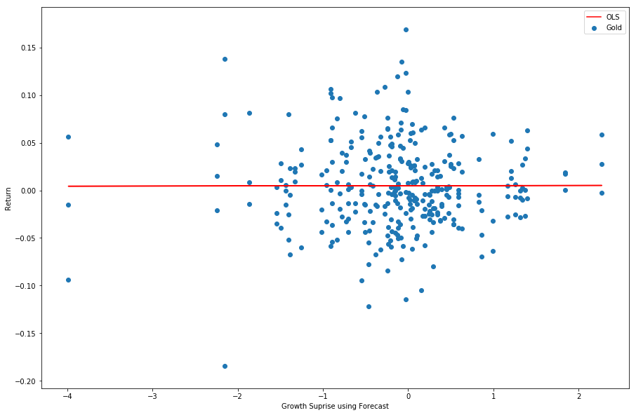

```
Beta of Gold to CPI Forecast Surprise Normalized: 0.0034
T statistic of Beta of Gold to CPI Forecast Surprise Normalized: 1.3614
```

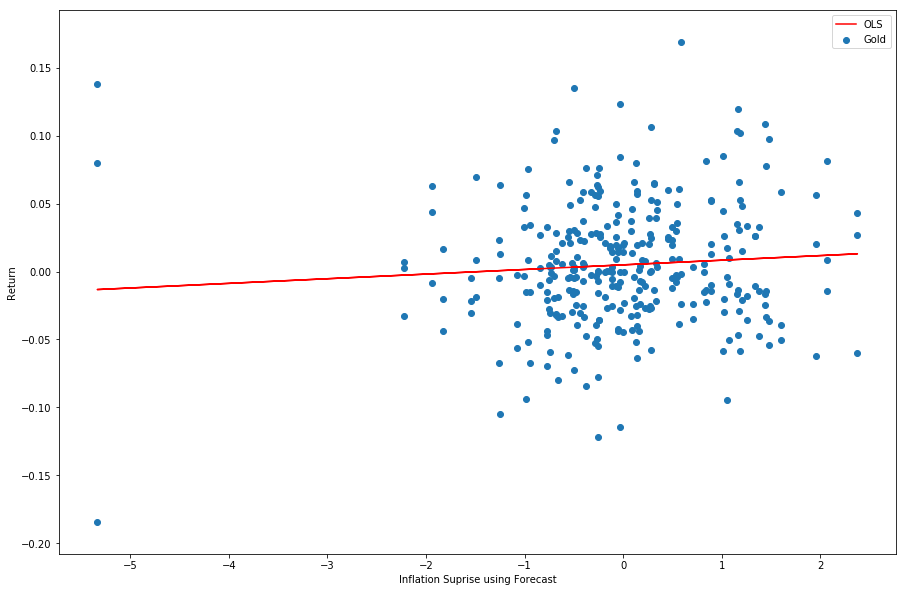

```
HY Spread
Beta of HY Spread to INDPRO Forecast Surprise Normalized: 0.0039
T statistic of Beta of HY Spread to INDPRO Forecast Surprise Normalized: 2.5930
```

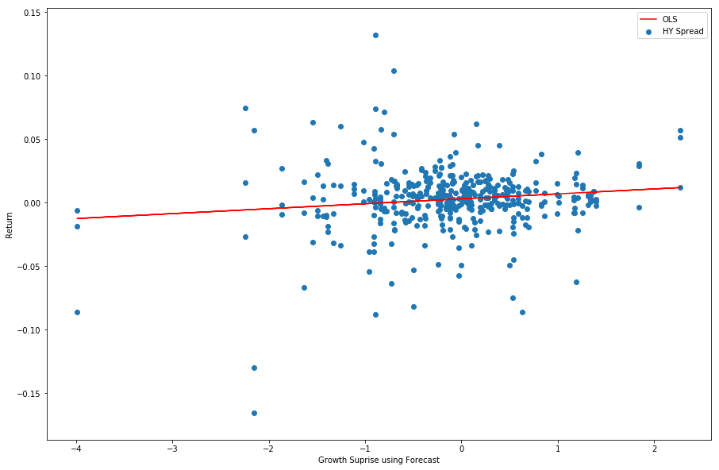

```
Beta of HY Spread to CPI Forecast Surprise Normalized: 0.0046
T statistic of Beta of HY Spread to CPI Forecast Surprise Normalized: 3.4657
```

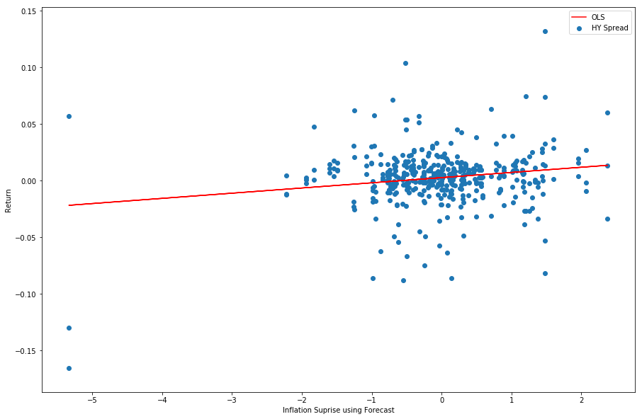

```
EM Spread
Beta of EM Spread to INDPRO Forecast Surprise Normalized: 0.0033
T statistic of Beta of EM Spread to INDPRO Forecast Surprise Normalized: 1.3695
```

[2 more figures not shown]

```python
for i,t in enumerate(tickers):
    print(t)
    plot_relationship(
        rdf2,
        t,
        'Growth',
        'Forecast'
    )

    plot_relationship(
        rdf2,
        t,
        'Inflation',
        'Forecast'
    )
    print('\n\n\n\n\n')
```